# HUDK4051: Prediction - Comparing Trees

Christina Huang

In this assignment you will modelling student data using three flavors of tree algorithm: CART, C4.5 and C5.0. We will be using these algorithms to attempt to predict which students drop out of courses. Many universities have a problem with students over-enrolling in courses at the beginning of semester and then dropping most of them as the make decisions about which classes to attend. This makes it difficult to plan for the semester and allocate resources. However, schools don’t want to restrict the choice of their students. One solution is to create predictions of which students are likley to drop out of which courses and use these predictions to inform semester planning.

In this assignment we will be using the tree algorithms to build models of which students are likely to drop out of which classes.

## Software

In order to generate our models we will need several packages. The first package you should install is [caret](https://cran.r-project.org/web/packages/caret/index.html).

There are many prediction packages available and they all have slightly different syntax. caret is a package that brings all the different algorithms under one hood using the same syntax.

We will also be accessing an algorithm from the [Weka suite](https://www.cs.waikato.ac.nz/~ml/weka/). Weka is a collection of machine learning algorithms that have been implemented in Java and made freely available by the University of Waikato in New Zealand. To access these algorithms you will need to first install both the [Java Runtime Environment (JRE) and Java Development Kit](http://www.oracle.com/technetwork/java/javase/downloads/jre9-downloads-3848532.html) on your machine. You can then then install the [RWeka](https://cran.r-project.org/web/packages/RWeka/index.html) package within R.

The last package you will need is [C50](https://cran.r-project.org/web/packages/C50/index.html).

```r
library (dplyr)
```

```r
library (tidyr)
library (ggplot2)
#install.packages('caret')
#install.packages("RWeka")
#install.packages("C50")
```

## Data

The data comes from a university registrar’s office. The code book for the variables are available in the file code-book.txt. Examine the variables and their definitions.

Upload the drop-out.csv data into R as a data frame.

```r
DF1 <- data.frame (read.csv("drop-out.csv"))
```

The next step is to separate your data set into a training set and a test set. Randomly select 25% of the students to be the test data set and leave the remaining 75% for your training data set. (Hint: each row represents an answer, not a single student.)

```r
#install.packages('caret', dependencies = TRUE)

library(caret)
set.seed (1000000)

trainData <- createDataPartition (
  y = DF1$student_id, ##the outcome data are needed
  p = 0.75, #the percentage of data in the training set
  list = FALSE
)

#generate a list of index numbers for the sample
training <- DF1 [trainData,]
testing <- DF1 [-trainData,]

summary (training)
```

```
##    student_id         years         entrance_test_score courses_taken
##  Min.   :172777   Min.   : 0.0000   Min.   :  0.00      Min.   : 1.00
##  1st Qu.:235106   1st Qu.: 0.0000   1st Qu.:  0.00      1st Qu.: 7.00
##  Median :247301   Median : 0.0000   Median :  1.60      Median :13.00
##  Mean   :253094   Mean   : 0.6296   Mean   : 11.45      Mean   :16.44
##  3rd Qu.:282338   3rd Qu.: 0.0000   3rd Qu.: 19.18      3rd Qu.:22.00
##  Max.   :299198   Max.   :10.0000   Max.   :121.70      Max.   :60.00
##    complete         enroll_date_time      course_id      international
##  Length:4398        Min.   :149369489   Min.   :658434   Length:4398
##  Class :character   1st Qu.:153066244   1st Qu.:658439   Class :character
##  Mode  :character   Median :156135894   Median :658467   Mode  :character
##                     Mean   :156263864   Mean   :697597
##                     3rd Qu.:159924215   3rd Qu.:807717
##                     Max.   :161511149   Max.   :807758
##     online              gender
##  Length:4398        Min.   :1.000
##  Class :character   1st Qu.:1.000
##  Mode  :character   Median :2.000
##                     Mean   :1.654
##                     3rd Qu.:2.000
##                     Max.   :5.000
```

```r
summary (testing)
```

```
##    student_id         years         entrance_test_score courses_taken
##  Min.   :172777   Min.   : 0.0000   Min.   :  0.00      Min.   : 1.00
##  1st Qu.:235111   1st Qu.: 0.0000   1st Qu.:  0.00      1st Qu.: 7.00
##  Median :247301   Median : 0.0000   Median :  1.90      Median :13.00
##  Mean   :252541   Mean   : 0.6869   Mean   : 11.37      Mean   :16.35
##  3rd Qu.:282338   3rd Qu.: 0.0000   3rd Qu.: 17.30      3rd Qu.:22.00
##  Max.   :299198   Max.   :10.0000   Max.   :121.70      Max.   :60.00
##    complete         enroll_date_time      course_id      international
##  Length:1463        Min.   :149369454   Min.   :658434   Length:1463
##  Class :character   1st Qu.:153066756   1st Qu.:658439   Class :character
##  Mode  :character   Median :155828550   Median :658467   Mode  :character
##                     Mean   :156231314   Mean   :697745
##                     3rd Qu.:159813641   3rd Qu.:807717
##                     Max.   :161510795   Max.   :807758
##     online              gender
##  Length:1463        Min.   :1.000
##  Class :character   1st Qu.:1.000
##  Mode  :character   Median :2.000
##                     Mean   :1.697
##                     3rd Qu.:2.000
##                     Max.   :5.000
```

For this assignment you will be predicting the student level variable “complete”. (Hint: make sure you understand the increments of each of your chosen variables, this will impact your tree construction)

Visualize the relationships between your chosen variables as a scatterplot matrix. Save your image as a .pdf named scatterplot_matrix.pdf. Based on this visualization do you see any patterns of interest? Why or why not?

```r
#install.packages("GGally")

pdf(file = "scatterplot_matrix.pdf")
DF2 <- select (DF1, -complete, -international, -online)
DF2
```

[output not shown]

[output cut: 11709 more lines]

```r
pairs (DF2)
dev.off ()
```

```r
##students with lower entrance test score have higher dropout rates
```

## CART Trees

You will use the [rpart package](https://cran.r-project.org/web/packages/rpart/rpart.pdf) to generate CART tree models.

Construct a classification tree that predicts complete using the caret package.

```r
library (rpart)

training2 <- training[,c(2:10)] #Remove the student_id variable that we do not want to use in the model

#caret does not summarize the metrics we want by default so we have to modify the output
MySummary  <- function(data, lev = NULL, model = NULL){
  df <- defaultSummary(data, lev, model)
  tc <- twoClassSummary(data, lev, model)
  pr <- prSummary(data, lev, model)
  out <- c(df,tc,pr)
  out}

#Define the control elements we would like to use
ctrl <- trainControl(method = "repeatedcv", #Tell caret to perform k-fold cross validation
                repeats = 3, #Tell caret to repeat each fold three times
                classProbs = TRUE, #Calculate class probabilities
                summaryFunction = MySummary)

#Define the model
cartFit <- train(complete ~ ., #Define which variable to predict
                data = training2, #Define the data set to train the model on
                trControl = ctrl, #Tell caret the control elements
                method = "rpart", #Define the model type
                metric = "Accuracy", #Final model choice is made according to sensitivity
                preProc = c("center", "scale")) #Center and scale the data to minimize the
#Check the results
cartFit
```

```
## CART
##
## 4398 samples
##    8 predictor
##    2 classes: 'no', 'yes'
##
## Pre-processing: centered (8), scaled (8)
## Resampling: Cross-Validated (10 fold, repeated 3 times)
## Summary of sample sizes: 3959, 3958, 3958, 3958, 3958, 3958, ...
## Resampling results across tuning parameters:
##
##   cp           Accuracy   Kappa      ROC        Sens       Spec       AUC
##   0.008668243  0.9002576  0.7298928  0.8872272  0.6614402  0.9971239  0.3019076
##   0.037825059  0.8852461  0.6829713  0.8352614  0.6059638  0.9985087  0.2866415
##   0.575256107  0.7777054  0.2667001  0.6147669  0.2295338  1.0000000  0.1313098
##   Precision  Recall     F
##   0.9892918  0.6614402  0.7918744
##   0.9942566  0.6059638  0.7515652
##   1.0000000  0.2295338  0.6920671
##
## Accuracy was used to select the optimal model using the largest value.
## The final value used for the model was cp = 0.008668243.
```

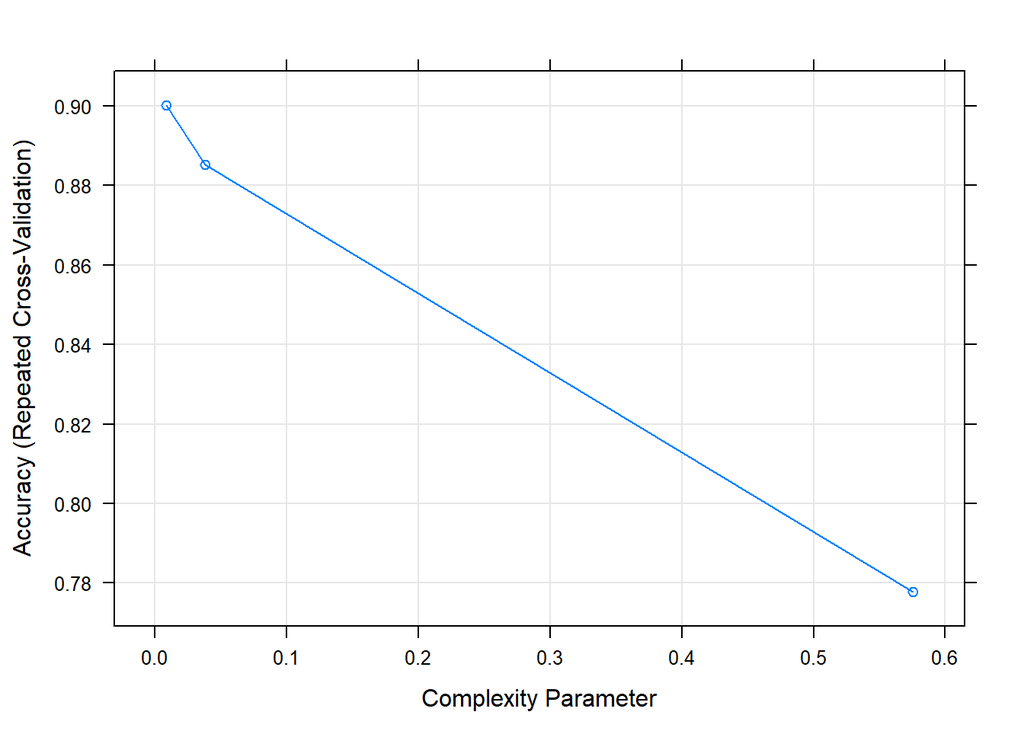

```r
plot(cartFit)
```

Describe important model attributes of your tree. Do you believe it is a successful model of student performance, why/why not? ##courses_taken - high accuracy, therefore successful model

Can you use the sensitivity and specificity metrics to calculate the F1 metric?

Now predict results from the test data and describe important attributes of this test. Do you believe it is a successful model of student performance, why/why not?

```r
testing2 <- testing [,c(2:10)] #Remove the student_id variable that we do not want to use in the model

#Generate prediction using previously trained model
cartClasses <- predict(cartFit, newdata = testing2)

#Generate model statistics
confusionMatrix(data = cartClasses, as.factor(testing2$complete))
```

```
## Confusion Matrix and Statistics
##
##           Reference
## Prediction   no  yes
##        no   291    8
##        yes  164 1000
##
##                Accuracy : 0.8824
##                  95% CI : (0.8648, 0.8985)
##     No Information Rate : 0.689
##     P-Value [Acc > NIR] : < 2.2e-16
##
##                   Kappa : 0.6972
##
##  Mcnemar's Test P-Value : < 2.2e-16
##
##             Sensitivity : 0.6396
##             Specificity : 0.9921
##          Pos Pred Value : 0.9732
##          Neg Pred Value : 0.8591
##              Prevalence : 0.3110
##          Detection Rate : 0.1989
##    Detection Prevalence : 0.2044
##       Balanced Accuracy : 0.8158
##
##        'Positive' Class : no
##
```

## Conditional Inference Trees

Train a Conditional Inference Tree using the `party` package on the same training data and examine your results.

```r
library (party)
require (party)

#Define the control elements we would like to use
ctrl <- trainControl(method = "repeatedcv", #Tell caret to perform k-fold cross validation
                repeats = 3, #Tell caret to repeat each fold three times
                classProbs = TRUE, #Calculate class probabilities
                summaryFunction = MySummary)

#Define the model
condFit <- train(complete ~ ., #Define which variable to predict
                data = training2, #Define the data set to train the model on
                trControl = ctrl, #Tell caret the control elements
                method = "ctree", #Define the model type
                metric = "ROC", #ROC calculation
                preProc = c("center", "scale")) #Center and scale the data to minimize the

#Check the results
condFit
```

```
## Conditional Inference Tree
##
## 4398 samples
##    8 predictor
##    2 classes: 'no', 'yes'
##
## Pre-processing: centered (8), scaled (8)
## Resampling: Cross-Validated (10 fold, repeated 3 times)
## Summary of sample sizes: 3958, 3958, 3959, 3958, 3958, 3959, ...
## Resampling results across tuning parameters:
##
##   mincriterion  Accuracy   Kappa      ROC        Sens       Spec
##   0.01          0.8924546  0.7180787  0.9012291  0.6950340  0.9725185
##   0.50          0.9005631  0.7327823  0.9059708  0.6719181  0.9932894
##   0.99          0.9011688  0.7329179  0.9004088  0.6645586  0.9971239
##   AUC        Precision  Recall     F
##   0.2379799  0.9126804  0.6950340  0.7883426
##   0.2402654  0.9766194  0.6719181  0.7954126
##   0.3044373  0.9896257  0.6645586  0.7945950
##
## ROC was used to select the optimal model using the largest value.
## The final value used for the model was mincriterion = 0.5.
```

```r
condFit$fitnalModel
```

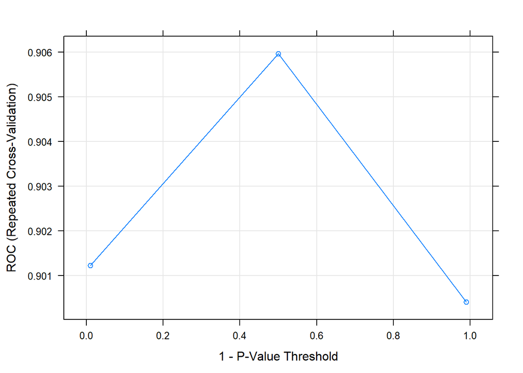

```r
plot(condFit)
```

```r
testing3 <- testing[,c(2:10)] #Remove the student_id variable that we do not want to use in the model

#Generate prediction using previously trained model
condClasses <- predict(condFit, newdata = testing3)

#Generate model statistics
confusionMatrix(data = condClasses, as.factor(testing3$complete))
```

```
## Confusion Matrix and Statistics
##
##           Reference
## Prediction   no  yes
##        no   306    8
##        yes  149 1000
##
##                Accuracy : 0.8927
##                  95% CI : (0.8757, 0.9081)
##     No Information Rate : 0.689
##     P-Value [Acc > NIR] : < 2.2e-16
##
##                   Kappa : 0.7263
##
##  Mcnemar's Test P-Value : < 2.2e-16
##
##             Sensitivity : 0.6725
##             Specificity : 0.9921
##          Pos Pred Value : 0.9745
##          Neg Pred Value : 0.8703
##              Prevalence : 0.3110
##          Detection Rate : 0.2092
##    Detection Prevalence : 0.2146
##       Balanced Accuracy : 0.8323
##
##        'Positive' Class : no
##
```

Describe important model attributes of your tree. Do you believe it is a successful model of student performance, why/why not? ##course_taken, entrance_test_score - high accuracy, therefore successful model

What does the plot represent? What information does this plot tell us?

Now test your new Conditional Inference model by predicting the test data and generating model fit statistics.

There is an updated version of the C4.5 model called C5.0, it is implemented in the C50 package. What improvements have been made to the newer version?

Install the C50 package, train and then test the C5.0 model on the same data.

```r
require (C50)
#Define the model
c50Fit <- train(complete ~ ., #Define which variable to predict
                data = training2, #Define the data set to train the model on
                trControl = ctrl, #Tell caret the control elements
                method = "C5.0", #Define the model type
                metric = "Accuracy", #Final model choice is made according to sensitivity
                preProc = c("center", "scale")) #Center and scale the data to minimize the

#Check the results
c50Fit
```

```
## C5.0
##
## 4398 samples
##    8 predictor
##    2 classes: 'no', 'yes'
##
## Pre-processing: centered (8), scaled (8)
## Resampling: Cross-Validated (10 fold, repeated 3 times)
## Summary of sample sizes: 3958, 3958, 3958, 3958, 3958, 3958, ...
## Resampling results across tuning parameters:
##
##   model  winnow  trials  Accuracy   Kappa      ROC        Sens       Spec
##   rules  FALSE    1      0.8995727  0.7282798  0.8291432  0.6606174  0.9964856
##   rules  FALSE   10      0.8994976  0.7294245  0.9205415  0.6679728  0.9933969
##   rules  FALSE   20      0.9007853  0.7326429  0.9240212  0.6692872  0.9946752
##   rules   TRUE    1      0.8995725  0.7282469  0.8289766  0.6606153  0.9964856
##   rules   TRUE   10      0.8993461  0.7288240  0.9201411  0.6663980  0.9938229
##   rules   TRUE   20      0.9005579  0.7319403  0.9223034  0.6682352  0.9947817
##   tree   FALSE    1      0.9013917  0.7341470  0.8850569  0.6692893  0.9955272
##   tree   FALSE   10      0.9004823  0.7323162  0.9199495  0.6713890  0.9933965
##   tree   FALSE   20      0.9010126  0.7341522  0.9223631  0.6745448  0.9928630
##   tree    TRUE    1      0.9008606  0.7324153  0.8765623  0.6669146  0.9957401
##   tree    TRUE   10      0.9007096  0.7329971  0.9200070  0.6721743  0.9933965
##   tree    TRUE   20      0.8998754  0.7313850  0.9219422  0.6737637  0.9915851
##   AUC        Precision  Recall     F
##   0.2777492  0.9875162  0.6606174  0.7907984
##   0.3030549  0.9769347  0.6679728  0.7925160
##   0.3109765  0.9815222  0.6692872  0.7948188
##   0.2657415  0.9875309  0.6606153  0.7907494
##   0.3025599  0.9783046  0.6663980  0.7919416
##   0.3089070  0.9818399  0.6682352  0.7942266
##   0.2997715  0.9841754  0.6692893  0.7959070
##   0.3011765  0.9768911  0.6713890  0.7948800
##   0.3080383  0.9751850  0.6745448  0.7965414
##   0.2998301  0.9849154  0.6669146  0.7943863
##   0.3022677  0.9769241  0.6721743  0.7954442
##   0.3069538  0.9707706  0.6737637  0.7946061
##
## Accuracy was used to select the optimal model using the largest value.
## The final values used for the model were trials = 1, model = tree and winnow
##  = FALSE.
```

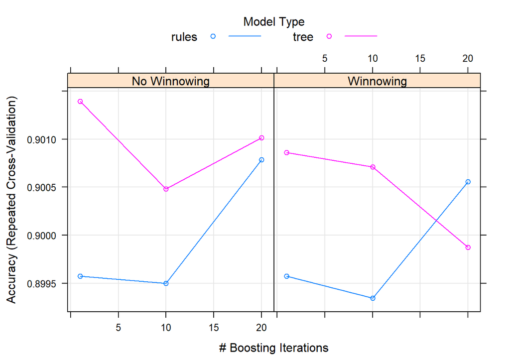

```r
plot (c50Fit)
```

```r
#Generate prediction using previously trained model
c50Classes <- predict(c50Fit, newdata = testing3)

#Generate model statistics
confusionMatrix(data = c50Classes, as.factor(testing3$complete))
```

```
## Confusion Matrix and Statistics
##
##           Reference
## Prediction  no yes
##        no  299  11
##        yes 156 997
##
##                Accuracy : 0.8859
##                  95% CI : (0.8684, 0.9017)
##     No Information Rate : 0.689
##     P-Value [Acc > NIR] : < 2.2e-16
##
##                   Kappa : 0.7081
##
##  Mcnemar's Test P-Value : < 2.2e-16
##
##             Sensitivity : 0.6571
##             Specificity : 0.9891
##          Pos Pred Value : 0.9645
##          Neg Pred Value : 0.8647
##              Prevalence : 0.3110
##          Detection Rate : 0.2044
##    Detection Prevalence : 0.2119
##       Balanced Accuracy : 0.8231
##
##        'Positive' Class : no
##
```

## Compare the models

caret allows us to compare all three models at once.

```r
resamps <- resamples(list(cart = cartFit, condinf = condFit, cfiveo = c50Fit))
summary(resamps)
```

```
##
## Call:
## summary.resamples(object = resamps)
##
## Models: cart, condinf, cfiveo
## Number of resamples: 30
##
## Accuracy
##              Min.   1st Qu.    Median      Mean   3rd Qu.      Max. NA's
## cart    0.8701595 0.8920455 0.9000000 0.9002576 0.9083674 0.9340909    0
## condinf 0.8795455 0.8920455 0.9032978 0.9005631 0.9083674 0.9272727    0
## cfiveo  0.8815490 0.8929993 0.9000000 0.9013917 0.9113132 0.9227273    0
##
## AUC
##              Min.   1st Qu.    Median      Mean   3rd Qu.      Max. NA's
## cart    0.2349503 0.2725279 0.2997273 0.3019076 0.3293598 0.3795149    0
## condinf 0.1892351 0.2208198 0.2376400 0.2402654 0.2615189 0.2892988    0
## cfiveo  0.2438742 0.2811740 0.2975791 0.2997715 0.3174039 0.3649244    0
##
## F
##              Min.   1st Qu.    Median      Mean   3rd Qu.      Max. NA's
## cart    0.7135678 0.7732830 0.7944099 0.7918744 0.8121387 0.8722467    0
## condinf 0.7450980 0.7774299 0.8027291 0.7954126 0.8141308 0.8571429    0
## cfiveo  0.7425743 0.7739686 0.7924528 0.7959070 0.8202765 0.8468468    0
##
## Kappa
##              Min.   1st Qu.    Median      Mean   3rd Qu.      Max. NA's
## cart    0.6377311 0.7065743 0.7313564 0.7298928 0.7542725 0.8286788    0
## condinf 0.6738644 0.7075190 0.7401629 0.7327823 0.7553045 0.8095290    0
## cfiveo  0.6721434 0.7079831 0.7299484 0.7341470 0.7637015 0.7966010    0
##
## Precision
##              Min.   1st Qu.    Median      Mean   3rd Qu. Max. NA's
## cart    0.9659091 0.9868848 0.9884389 0.9892918 1.0000000    1    0
## condinf 0.9213483 0.9648271 0.9871774 0.9766194 0.9974227    1    0
## cfiveo  0.9583333 0.9762605 0.9880201 0.9841754 0.9888889    1    0
##
## Recall
##              Min.   1st Qu.    Median      Mean   3rd Qu.      Max. NA's
## cart    0.5590551 0.6377953 0.6692913 0.6614402 0.6850394 0.7795276    0
## condinf 0.5984252 0.6469504 0.6732283 0.6719181 0.7001937 0.7559055    0
## cfiveo  0.5905512 0.6356393 0.6614173 0.6692893 0.7007874 0.7401575    0
##
## ROC
##              Min.   1st Qu.    Median      Mean   3rd Qu.      Max. NA's
## cart    0.8563623 0.8751226 0.8870343 0.8872272 0.8998491 0.9241721    0
## condinf 0.8672360 0.8968957 0.9081910 0.9059708 0.9164726 0.9379890    0
## cfiveo  0.7989736 0.8433058 0.9033295 0.8850569 0.9193259 0.9452970    0
##
## Sens
##              Min.   1st Qu.    Median      Mean   3rd Qu.      Max. NA's
## cart    0.5590551 0.6377953 0.6692913 0.6614402 0.6850394 0.7795276    0
## condinf 0.5984252 0.6469504 0.6732283 0.6719181 0.7001937 0.7559055    0
## cfiveo  0.5905512 0.6356393 0.6614173 0.6692893 0.7007874 0.7401575    0
##
## Spec
##              Min.   1st Qu.    Median      Mean   3rd Qu. Max. NA's
## cart    0.9904153 0.9967974 0.9968051 0.9971239 1.0000000    1    0
## condinf 0.9776358 0.9904153 0.9968051 0.9932894 0.9992013    1    0
## cfiveo  0.9872204 0.9936102 0.9968051 0.9955272 0.9968051    1    0
```

What does the model summary tell us? Which model do you believe is the best? ##c50

Which variables (features) within your chosen model are important, do these features provide insights that may be useful in solving the problem of students dropping out of courses? ##courses_taken